# EAS648 Lab05

### Fitting the Model

```r
###Grab all the developed cells (presence)
newUrban <- SL %>%
  filter(urbanChg == TRUE)

###Grab all the nondeveloped and not previously urban cells (absence)
nonUrban <- SL %>%
  filter(urbanChg == FALSE)

###Get a random sample of the absence data
### that is twice as large as the presence data
index <- sample(1:nrow(nonUrban), (round(nrow(newUrban)* 2)))
SLsampleUrban <- nonUrban[index, ]

### combine the original presence and absence data
SLsample <- rbind(SLsampleUrban, newUrban)

###Consider making a training and testing dataset
###This can reduce the computational burden
### It also is a robust goodness of fit method
SLsample <- SLsample %>% dplyr::mutate(id = row_number())
#Create training set
train <- SLsample %>% sample_frac(.70)
#Create test set
test  <- anti_join(SLsample, train, by = 'id')
```

> Fit a Model

```r
fit <- glm(urbanChg ~ Parks_dist_SL + Rd_dns1km_SL + WaterDist_SL + DEM_SL,data=train,family=binomial())
summary(fit)
```

```
##
## Call:
## glm(formula = urbanChg ~ Parks_dist_SL + Rd_dns1km_SL + WaterDist_SL +
##     DEM_SL, family = binomial(), data = train)
##
## Coefficients:
##                 Estimate Std. Error z value Pr(>|z|)
## (Intercept)    4.296e+00  6.806e-02   63.12   <2e-16 ***
## Parks_dist_SL  1.073e-04  1.609e-06   66.69   <2e-16 ***
## Rd_dns1km_SL   2.095e+01  1.168e-01  179.30   <2e-16 ***
## WaterDist_SL   2.050e-04  8.502e-06   24.11   <2e-16 ***
## DEM_SL        -5.207e-03  5.135e-05 -101.39   <2e-16 ***
## ---
## Signif. codes:  0 '***' 0.001 '**' 0.01 '*' 0.05 '.' 0.1 ' ' 1
##
## (Dispersion parameter for binomial family taken to be 1)
##
##     Null deviance: 281124  on 220709  degrees of freedom
## Residual deviance: 115834  on 220705  degrees of freedom
## AIC: 115844
##
## Number of Fisher Scoring iterations: 7
```

### Test the Model

> Test the data

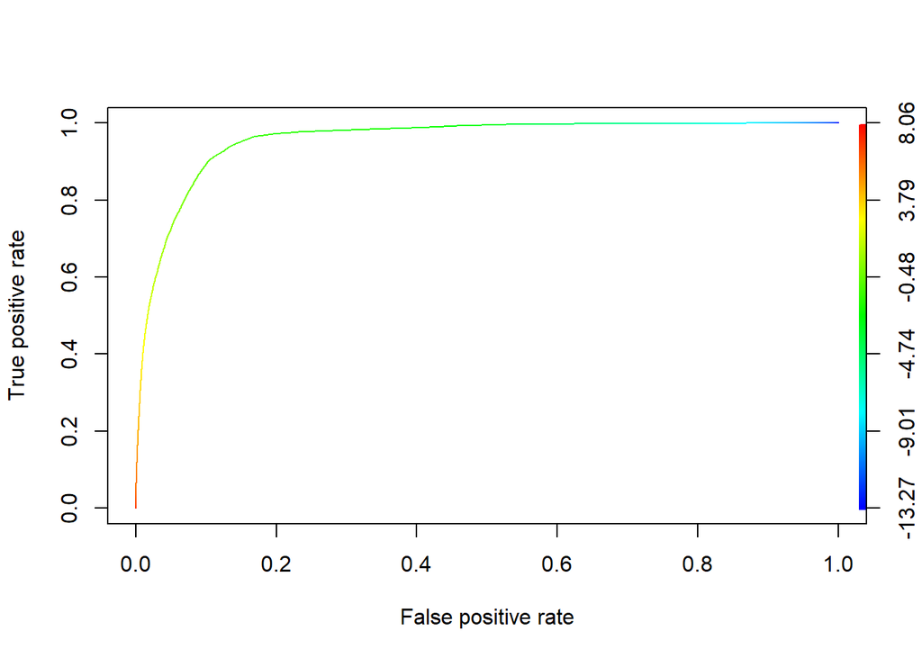

```r
## Loading required package: ggplots
library(ROCR)
# plot a ROC curve for a single prediction run
# and color the curve according to cutoff.
pred <- prediction(predict(fit, newdata = test), test$urbanChg)
perf <- performance(pred,"tpr","fpr")
plot(perf,colorize=TRUE)
```

```r
## A simpler way to understand these result is to calculate the
## area under the curve(AUC). The closer this number is to 1, the
## better your model fit
auc_ROCR <- performance(pred, measure = "auc")
auc_ROCR <- auc_ROCR@y.values[[1]]
auc_ROCR
```

```
## [1] 0.9567307
```

### Predict the Result Using the Model

```r
predicted = predict(allrasters, fit)
```

```
##
|---------|---------|---------|---------|
=========================================
```

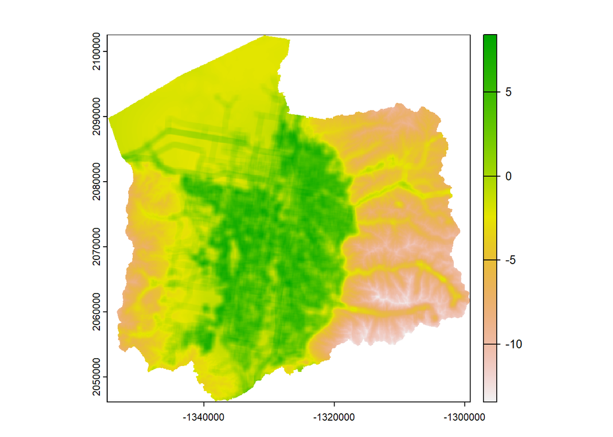

```r
plot(predicted)
```

> **Analysing the Fitting Goodness**

> The goodness of the fitting result can be assessed by two aspects:
> 1. As shown by the `summary(fit)` result, all the explanatory variables are significant for the explaining the changed areas.
> 2. The ROC line is steep at the beginning and AUC is close to 1. Thus the model is good in fitting the result.

> **What variable might you add to better explain urban development**
> - **Normalized Difference Vegetation Index (NDVI)**: This index, derived from satellite imagery, measures vegetation health and coverage. It can be used to monitor green spaces within urban areas.
> - **Air Quality Indices**: Using satellite data, it’s possible to estimate the concentration of different pollutants, providing insights into environmental aspects of urban areas.
> - **Nighttime Lights**: Satellite imagery of nighttime lights is often used as a proxy for urbanization and economic activity.
> - **Land Surface Temperature**: Using thermal imagery, land surface temperature can be a good indicator of urban heat islands and overall urbanization levels.
> - …

## Part II: Cluster Analysis of Landscape Characteristics

> Task:

> Analyze the database of amenity landscape characteristics using a clustering technique. Choose variables based on a thematic inquiry of your choice. Visualize ad provide qualitative descriptions of the groups that you derive from the clustering techniques. Provide evidence of you characterizations. Provide a map of your cluster analysis. Give an explanation of the spatial distribution of these groups. (1-2 paragraphs)

### Loading the Data

```r
library(fastcluster)
```

```r
library(graphics)
library(ggplot2)
library(ggdendro)

library(sf)
amenData<- st_read("Lab5prj/AmenDataAll.shp")
# head(amenData)
```

```r
geomData = st_sfc(amenData$geometry)
```

### Pre-Process

> Here I continue to use the set of variables from the tutorial to show amenity: - Distance to zoo `ZooDistEmp` - Distance to hotel `HotelDistE` - Distance to an unknown feature `HistMon_Di` - Distance to higher education `HigherEdDi` - Distance to golf site `GolfDistEm` - Distance to coast `distcoast`

```r
# log transform the distance to show importance of nearness
amenData$ZooEmpDist_log <- log(amenData$ZooDistEmp + 0.00000001)
amenData$HotelEmpDist_log <- log(amenData$HotelDistE + 0.00000001)
amenData$HistMonDist_log <- log(amenData$HistMon_Di + 0.00000001)
amenData$HighEdEmpDist_log <- log(amenData$HigherEdDi + 0.00000001)
amenData$GolfEmpDist_log <- log(amenData$GolfDistEm + 0.00000001)
amenData$distcoast_log <- log(amenData$distcoast + 0.00000001)

# amenData$SocialNorm <- amenData$Nat_Flickr/(amenData$serPop10 + 1)
# amenData$HousingChg <- amenData$Urb2011 - amenData$Urb2001

amenDataDF<-amenData[,c("distcoast_log", "ZooEmpDist_log", "HotelEmpDist_log","HistMonDist_log", "HighEdEmpDist_log", "GolfEmpDist_log")]

## make sure there are no missing data
amenDataDF <- na.omit(amenDataDF)
## we need to make it into a normal dataframe to
## do the analysis
amenDataDF <- as.data.frame(amenDataDF)[1:6]
## calculate z-scores for the dataset
db_scaled <- scale(amenDataDF)
```

### K-means clustering

> Determine the number of clusters

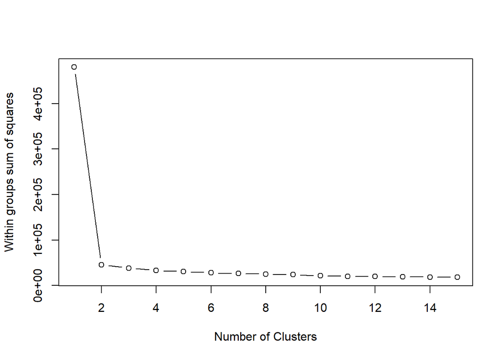

```r
# Determine number of clusters
wss <- (nrow(db_scaled)-1)*sum(apply(db_scaled,2,var))
for (i in 2:15) wss[i] <- sum(kmeans(db_scaled,
   centers=i)$withinss)
plot(1:15, wss, type="b", xlab="Number of Clusters",
  ylab="Within groups sum of squares")
```

> Based on the graph, 3 cluster would be enough to classify the points

```r
# K-Means Cluster Analysis
fit_new <- kmeans(db_scaled, 3) # 3 cluster solution
# get cluster means
cluster_means = aggregate(db_scaled,by=list(fit_new$cluster),FUN=mean)
cluster_means$Group.1 = as.factor(cluster_means$Group.1)
cluster_means
```

```
##   Group.1 distcoast_log ZooEmpDist_log HotelEmpDist_log HistMonDist_log
## 1       1     0.1910249      0.1768522        0.1876527       0.1883689
## 2       2    -4.9999306     -4.8483172       -4.9382400      -4.9810208
## 3       3     0.1775885      0.1942809        0.1780721       0.1820108
##   HighEdEmpDist_log GolfEmpDist_log
## 1      -0.002839913       0.1887934
## 2      -4.737587671      -4.9886419
## 3       0.652592318       0.1819301
```

> Plot the Data

```r
library(ggspatial)
library(grid)
```

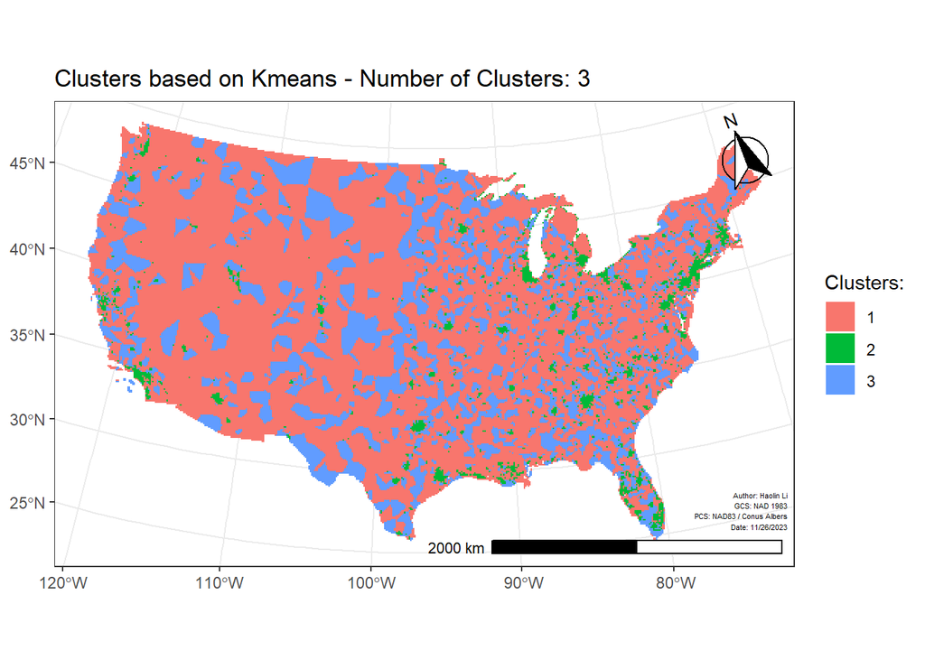

```r
library(cowplot)
# append cluster assignment
amenData <- data.frame(amenData, fit_new$cluster)

st_geometry(amenData) <- geomData

# Create grobs annotation
label_text <- "Author: Haolin Li\nGCS: NAD 1983\nPCS: NAD83 / Conus Albers\nDate: 11/26/2023"
text_grob <- textGrob(label = label_text,
                     hjust = 1, vjust = 0,
                     gp = gpar(fontsize = 4))

text_grob <- editGrob(text_grob,x = unit(0.99, "npc"), y = unit(0.08, "npc"))

ggplot() +
  geom_sf(data = amenData, mapping = aes(fill = as.factor(fit_new.cluster)), color = NA) +
  ggtitle("Clusters based on Kmeans - Number of Clusters: 3") +
  labs(fill = "Clusters:") +
  # adding north arrow
  annotation_north_arrow(location = "tr", which_north = "true",
                         style = north_arrow_fancy_orienteering()) +
  # adding scale bar
  annotation_scale(location = "br", width_hint = 0.5) +
  # add annotion
  annotation_custom(grob = text_grob) +
  theme_bw()
```

### Discussion

> Plot the line graph to indicate the meaning of the 3 clusters:

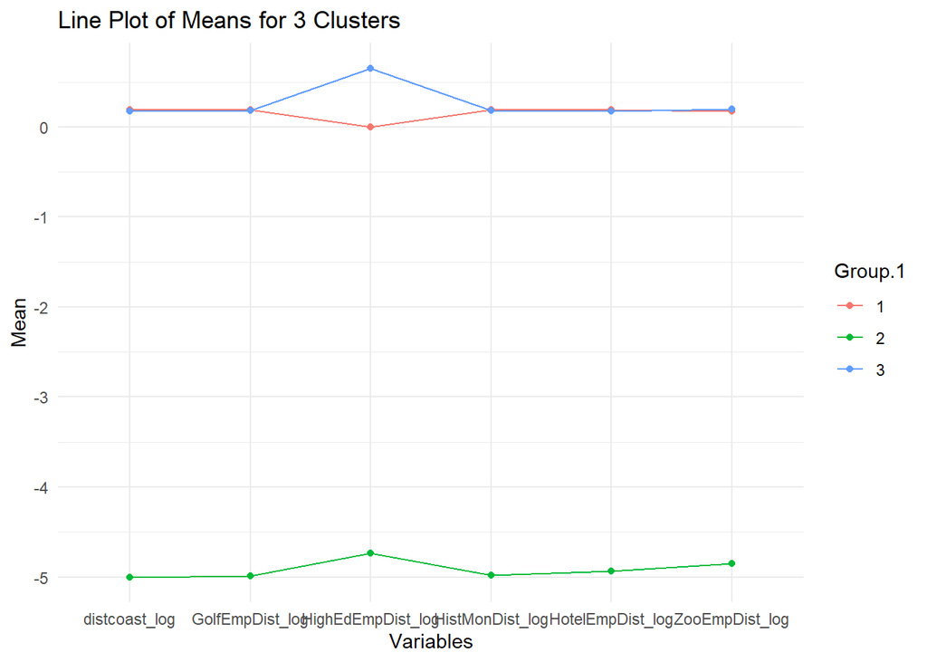

```r
df_long <- gather(cluster_means, key = "Variable", value = "Value", -Group.1)

ggplot(df_long, aes(x = Variable, y = Value, group = Group.1, color = Group.1)) +
  geom_line() +
  geom_point() +
  theme_minimal() +
  labs(title = "Line Plot of Means for 3 Clusters", x = "Variables", y = "Mean")
```

> These characteristics are also shown on the map

> The End of Lab 05

## **References**

> 1. https://chat.openai.com/
> 2. https://en.wikipedia.org/wiki/Moran%27s_I
> 3. https://humblepasty.github.io/EAS648/Lab/01/#Part_II:_Assignment_Tasks